# Data 558 Homework 1

Cathy Jia

Due Friday April 19, 2019, by 11:59pm

```python
# Display all of the results.
from IPython.core.interactiveshell import InteractiveShell
InteractiveShell.ast_node_interactivity = "all"
# Hide warnings
import warnings
warnings.filterwarnings('ignore')
```

# Exercise 1

### (a)

**Assume that $d=1$ and $n=1$. The sample is the $n$ of size 1 and boils down to just $(x, y)$. The function $F$ writes simply as** $$F(\beta) = (y-x\beta)^2 + \lambda\beta^2.$$ **Compute and write down the gradient $\nabla F$ of $F$.**

$\space\space\space\space\nabla F$

$= 2(y-x\beta)(0-x) + 2\lambda \beta\space\space\space\space$(Apply Chain rule)

$= -2x(y-x\beta)+2\lambda \beta$

### (b)

**Assume now that $d > 1$ and $n > 1$. Using the previous result and the linearity of differentiation, compute and write down the gradient $\nabla F(\beta)$ of $F$.**

We have $$F(\beta) = \frac{1}{n} \sum_{i=1}^n (y_i-x_i^T\beta)^2 + \lambda\mid\mid\beta\mid\mid_2^2$$

We can write $$F(\beta) = g(\beta) + h(\beta)$$

$$ where \space g(\beta) = \frac{1}{n} \sum_{i=1}^n (y_i-x_i^T\beta)^2, h(\beta) = \lambda\mid\mid\beta\mid\mid_2^2$$

So the gradient $\nabla F(\beta)$ of $F$ can be written as $$\nabla F(\beta) = \frac{\delta g}{\delta\beta} + \frac{\delta h}{\delta\beta}$$

We can first derive $\frac{\delta g}{\delta\beta}$. Notice that we can rewrite $$g(\beta) = \frac{1}{n} \sum_{i=1}^n (y_i-x_i^T\beta)^2$$

$$= \frac{1}{n} \mid\mid Y-X^T\beta \mid\mid_2^2$$$$= \frac{1}{n}\{(Y-X^T\beta)^T(Y-X^T\beta)\}$$$$= \frac{1}{n}\{Y^T Y - Y^T X^T \beta - (X^T \beta)^T Y + (X^T \beta)^T X^T \beta))\}$$$$= \frac{1}{n}\{Y^T Y - Y^T X^T \beta - \beta ^T XY + \beta ^T XX^T \beta\}$$

So we have $$\frac{\delta g}{\delta\beta} = \frac{1}{n} \{ \frac{\delta}{\delta\beta}(Y^T Y) - \frac{\delta}{\delta\beta}(Y^T X^T \beta) - \frac{\delta}{\delta\beta}(\beta ^T XY) + \frac{\delta}{\delta\beta}(\beta ^T XX^T \beta) \}$$

Using the Hammer Identity, for any $A$, $$\frac{\delta}{\delta x}(A^T x) = \frac{\delta}{\delta x}(x^T A) = A,$$

we have

$$\frac{\delta}{\delta\beta}(Y^T Y) = 0$$$$\frac{\delta}{\delta\beta}(Y^T X^T \beta) = \frac{\delta}{\delta\beta}((XY)^T \beta) = \frac{\delta}{\delta\beta}(\beta ^T (XY)) = XY$$$$\frac{\delta}{\delta\beta}(\beta ^T XY) = \frac{\delta}{\delta\beta}(\beta ^T (XY)) = XY$$$$\frac{\delta}{\delta\beta}(\beta ^T XX^T \beta) = \frac{\delta}{\delta\beta}\beta ^T (XX^T) \beta = (XX^T + (XX^T)^T)\beta = (XX^T + XX^T)\beta = 2XX^T \beta$$

Therefore, $$\frac{\delta g}{\delta\beta} = \frac{1}{n}\{0 - XY - XY + 2XX^T \beta\} = \frac{1}{n}\{-2XY + 2XX^T \beta\} = -\frac{2}{n}X(Y-X^T \beta)$$

Now let's derive $\frac{\delta h}{\delta\beta}$ using the Hammer Identity, for any $A$, $$\frac{\delta(X^T AX)}{\delta X} = (A+A^T)X$$

Then we get $$\frac{\delta h}{\delta\beta} = \frac{\delta(\lambda\mid\mid \beta \mid\mid_2^2)}{\delta\beta} = \lambda\frac{\delta(\mid\mid \beta \mid\mid_2^2)}{\delta\beta} = \lambda\frac{\delta(\beta^T \beta)}{\delta\beta} = \lambda(I + I^T)\beta = 2\lambda\beta$$

Thus, $$\nabla F(\beta) = \frac{\delta g}{\delta\beta} + \frac{\delta h}{\delta\beta} = -\frac{2}{n}X(Y-X^T \beta) + 2\lambda\beta$$

### (c)

**Consider the `Hitters` dataset, which you should load and divide into training and test sets using the code below.**

```python
import pandas as pd
from sklearn.model_selection import train_test_split
from sklearn import preprocessing

# Load the data
hitters = pd.read_csv('https://raw.githubusercontent.com/selva86/datasets/master/Hitters.csv', sep=',', header=0)
hitters = hitters.dropna()

# Create our X matrix with the predictors and y vector with the response
X = hitters.drop('Salary', axis=1)
X = pd.get_dummies(X, drop_first=True)
y = hitters.Salary

# Divide the data into training and test sets. By default, 25% goes into the test set.
X_train, X_test, y_train, y_test = train_test_split(X, y, random_state=0)
```

**Standardize the data. Note that you can convert a data frame into an array by using `np.array()`.**

```python
import numpy as np

# Standardize the data
X_train = preprocessing.scale(np.array(X_train)).T
y_train = preprocessing.scale(np.array(y_train)).T
X_test = preprocessing.scale(np.array(X_test)).T
y_test = preprocessing.scale(np.array(y_test)).T
```

### (d)

**Write a function `computegrad` that computes and returns $\nabla F(\beta)$ for any $\beta$. Avoid using for loops by vectorizing the computation.**

```python
def computegrad(X,Y,beta,lamb):
    """
    Compute and returns gradient
    """
    n = X.shape[1]
    return (-(2/n)*X.dot(Y-X.T.dot(beta))+2*lamb*beta)
```

### (e)

**Write a function `graddescent` that implements the gradient descent algorithm described in Algorithm 1. The function `graddescent` calls the function `computegrad` as a sub-routine. The function takes as input the initial point, the constant step-size value, and the maximum number of iterations. The stopping criterion is the maximum number of iterations.**

```python
def graddescent(X, Y, init, eta, max_iter, lamb, eps=0.001):
    """
    Gradient Descent Algorithm
    input: step-size 𝜂
    initialization: 𝛽0 = 0
    repeat for t = 0,1,2,...
           𝛽t+1 = 𝛽t - 𝜂 * ∇F(𝛽)
    until the stoppeing criterion
    """
    beta = init
    grad = computegrad(X, Y, beta, lamb)
    vals = [beta]
    t = 0
    # The stopping criterion is max_iter
    while np.linalg.norm(grad) > eps and t < max_iter:
        beta = beta - eta * grad
        vals.append(beta) # save beta
        grad = computegrad(X, Y, beta, lamb)
        t = t + 1
    return np.array(vals)
```

### (f)

**Set the constant step-size to $\eta$ = 0.05 and the maximum number of iterations to 1000. Run `graddescent` on the training set of the `Hitters` dataset for $\lambda$ = 0.05. Plot the curve of the objective value $F(\beta _t)$ versus the iteration counter $t$. (Again, avoid using for loops when computing the objective values). What do you observe?**

```python
def obj(X,Y,beta,lamb):
    """
    Compute objective value
    """
    n = X.shape[1]
    return 1/n*np.linalg.norm(Y-X.T.dot(beta))**2+lamb*np.linalg.norm(beta)**2
```

```python
import matplotlib.pyplot as plt

def obj_plot(X,Y,x_vals,lamb):
    """
    Plot objection value over iterations
    """
    n = x_vals.shape[0] # number of iterations
    fs = np.zeros(n)
    for i in range(n):
        fs[i] = obj(X,Y,x_vals[i],lamb)
    plt.figure()
    plt.plot(fs)
    plt.xlabel('Iteration')
    plt.ylabel('Objective Value')
    plt.title('Objective Value over Iterations', fontsize=16)
    plt.show()
    return
```

```python
# Set the constant step-size to eta = 0.05
# Set the maximum number of iterations to max_iter = 1000
# Run graddescent on the training set of Hitters for lambda = 0.05
vals = graddescent(X_train, y_train, init=np.zeros(19,), eta=0.05, max_iter=1000, lamb=0.05)
```

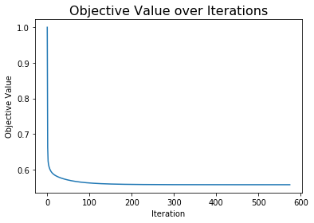

```python
# Plot
obj_plot(X_train, y_train, x_vals=vals, lamb=0.05)
```

From the plot of the objective value versus the iteration counter, we can see the objective value $F(\beta _t)$ is decreasing as the iteration counter $t$ increases. This satisfy our optimization goal to minimize the objective value $F(\beta _t)$.

### (g)

**Denote $\beta _T$ the final iterate of your gradient descent algorithm. Compare $\beta _T$ to the $\beta ^*$ found by `sklearn.linear model.Ridge`. Compare the objective value for $\beta _T$ to the one for $\beta ^*$. What do you observe?**

```python
def obj_ridge(X,Y,beta,lamb):
    """
    Compute objective value
    """
    return np.linalg.norm(X.T.dot(beta)-Y)**2+lamb*np.linalg.norm(beta)**2
```

```python
from sklearn.linear_model import Ridge

# Find beta_T by gradient sedcent algorithm
vals = graddescent(X_train, y_train, init=np.zeros(19,), eta=0.05, max_iter=1000, lamb=0.05)
beta_T = vals[vals.shape[0]-1]
beta_T_obj = obj(X_train, y_train, beta_T, lamb=0.05)

# Find beta_star by Ridge model
model = Ridge(alpha=0.05)
ridge = model.fit(X_train.T, y_train.T)
beta_star = model.coef_
beta_star_obj = obj_ridge(X_train, y_train, beta_star, lamb=0.05)

print('beta_T =')
print(beta_T)
print('\nbeta^* =')
print(beta_star)
print('\nThe objective value for beta_T = %.8f' % beta_T_obj)
print('\nThe objective value for beta^* = %.8f' % beta_star_obj)
```

```
beta_T =
[-0.22871546  0.28366856  0.07400629  0.01362956  0.05326721  0.1932022
 -0.08546881  0.0364336   0.30369615 -0.05685063  0.28756799  0.08549863
 -0.20074699  0.13210908  0.05462269 -0.0859081   0.04098798 -0.12653246
 -0.0055603 ]

beta^* =
[-0.58189403  0.62587485  0.17724106 -0.15728473 -0.00685988  0.32609641
 -0.05312767 -1.02026768  1.21078873  0.01548569  0.65742817 -0.0501934
 -0.39846507  0.15490523  0.12881244 -0.09288358  0.05634962 -0.12033263
 -0.02367366]

The objective value for beta_T = 0.55732772

The objective value for beta^* = 99.50884034
```

The $\beta_T$ is different from $\beta^*$. The objective value for $\beta_T$ is much smaller than the objective value for $\beta^*$.

Notice that for the gradient descent algorithm, the optimization problem minimize:

$$\frac{1}{n}\mid\mid Y-X^T \beta \mid\mid_2^2 + \lambda\mid\mid\beta\mid\mid_2^2$$

in which $\beta_T$ achieves the minimized objective value.

For Ridge regression, the ridge coefficients minimize a penalized residual sum of squares (From ocumentation: https://scikit-learn.org/stable/modules/generated/sklearn.linear_model.Ridge.html)

$$\mid\mid Y-X^T \beta \mid\mid_2^2 + \lambda\mid\mid\beta\mid\mid_2^2$$

in which $\beta^*$ achieves the minimized objective value.

### (h)

**Run your gradient algorithm for many values of $\eta$ on a logarithmic scale. Find the final iterate, across all runs for all the values of $\eta$, that achieves the smallest value of the objective. Compare $\beta _T$ to the $\beta ^*$ found by `sklearn.linear_model.Ridge`. Compare the objective value for $\beta _T$ to the $\beta ^*$. What conclusion to you draw?**

```python
# Run for different eta on a lafarithmic scale
# Find beta_T with smallest objective by gradient sedcent algorithm
min_obj = 10000
count = 1
while count < 4:
    eta = np.log(count) # choose different eta on a logarithmic scale
    vals = graddescent(X_train, y_train, init=np.zeros(19,), eta=eta, max_iter=1000, lamb=0.05)
    beta = vals[vals.shape[0]-1]
    beta_obj = obj(X_train, y_train, beta, lamb=0.05)
    if beta_obj < min_obj:
        min_obj = beta_obj # update minimum objective value
        beta_T = beta # update beta_T
    count += 0.01
beta_T_obj = min_obj

# Find beta_star by Ridge model
model = Ridge(alpha=0.05)
ridge = model.fit(X_train.T, y_train.T)
beta_star = model.coef_
beta_star_obj = obj_ridge(X_train, y_train, beta_star, lamb=0.05)

print('beta_T =')
print(beta_T)
print('\nbeta^* =')
print(beta_star)
print('\nThe objective value for beta_T = %.8f' % beta_T_obj)
print('\nThe objective value for beta^* = %.8f' % beta_star_obj)
```

```
beta_T =
[-0.22874207  0.2836952   0.07401234  0.01362182  0.05326155  0.19321068
 -0.08546906  0.03642375  0.30370488 -0.0568471   0.28758108  0.08549579
 -0.20076082  0.13210966  0.05462528 -0.08590748  0.04098752 -0.12653225
 -0.00556033]

beta^* =
[-0.58189403  0.62587485  0.17724106 -0.15728473 -0.00685988  0.32609641
 -0.05312767 -1.02026768  1.21078873  0.01548569  0.65742817 -0.0501934
 -0.39846507  0.15490523  0.12881244 -0.09288358  0.05634962 -0.12033263
 -0.02367366]

The objective value for beta_T = 0.55732768

The objective value for beta^* = 99.50884034
```

For the same reason as above, the $\beta_T$ is different from $\beta^*$. The objective value for $\beta_T$ is much smaller than the objective value for $\beta^*$.

We can draw a conclusion here: For all $\eta$ values run on a logarithmic scale, we can find a final iterate $\beta_T$ that achieves the smallest value of the objective. In this problem, the final iterate for the gradient descent algorithm gives a smaller objective value than the final iterate for Ridge regression model because these two algorithms solve different optimization problem.

# Exercise 2

**This question involves the use of simple linear regression on the `Auto` data set.**

### (a)

**Read in the dataset. The data can be downloaded from this url: http://www-bcf.usc.edu/~gareth/ISL/Auto.csv When reading in the data use the option na values=`'?'`. Then drop all NaN values using `dropna()`.**

```python
import pandas as pd
auto = pd.read_csv('Auto.csv', sep=',', header=0)
auto['horsepower'] =  pd.to_numeric(auto['horsepower'], errors='coerce')
auto = auto.dropna(axis=0)
```

### (b)

**Use the `OLS` function from the `statsmodels` package to perform a simple linear regression with `mpg` as the response and `weight` as the predictor. Be sure to include an intercept. Use the `summary()` attribute to print the results. Comment on the output.**

**Hint: See this URL for help with the `statsmodels` functions: http://www.statsmodels.org/dev/regression.html#examples**

```python
import statsmodels.api as sm
X = sm.add_constant(auto['weight'])
model = sm.OLS(auto['mpg'], X)
results = model.fit()
print(results.summary())
```

```
                            OLS Regression Results
==============================================================================
Dep. Variable:                    mpg   R-squared:                       0.693
Model:                            OLS   Adj. R-squared:                  0.692
Method:                 Least Squares   F-statistic:                     878.8
Date:                Thu, 18 Apr 2019   Prob (F-statistic):          6.02e-102
Time:                        22:47:07   Log-Likelihood:                -1130.0
No. Observations:                 392   AIC:                             2264.
Df Residuals:                     390   BIC:                             2272.
Df Model:                           1
Covariance Type:            nonrobust
==============================================================================
                 coef    std err          t      P>|t|      [0.025      0.975]
------------------------------------------------------------------------------
const         46.2165      0.799     57.867      0.000      44.646      47.787
weight        -0.0076      0.000    -29.645      0.000      -0.008      -0.007
==============================================================================
Omnibus:                       41.682   Durbin-Watson:                   0.808
Prob(Omnibus):                  0.000   Jarque-Bera (JB):               60.039
Skew:                           0.727   Prob(JB):                     9.18e-14
Kurtosis:                       4.251   Cond. No.                     1.13e+04
==============================================================================

Warnings:
[1] Standard Errors assume that the covariance matrix of the errors is correctly specified.
[2] The condition number is large, 1.13e+04. This might indicate that there are
strong multicollinearity or other numerical problems.
```

**(i) Is there a relationship between the predictor and the response?**

The p-value of the F-statistic is 6.02e-102, which is pretty closed to zero, so we reject the null hypothesis. There is a relationship between weight and mpg.

**(ii) How strong is the relationship between the predictor and the response?**

The R-squared 0.693 indicates that 69.3% of the variance in mpg is due to weight.

**(iii) Is the relationship between the predictor and the response positive or negative?**

Notice that the coefficient -0.0076 is negative, so the relationship between weight and mpg is negative.

### (c)

**Plot the response and the predictor using the `plot_fit` function (http://www.statsmodels.org/dev/generated/statsmodels.graphics.regressionplots.plot_fit.html)**

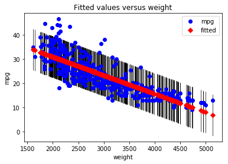

```python
import statsmodels as sm
plot = sm.graphics.regressionplots.plot_fit(results, exog_idx=1)
```

### (d)

**Plot the residuals vs. fitted values. Comment on any problems you see with the fit.**

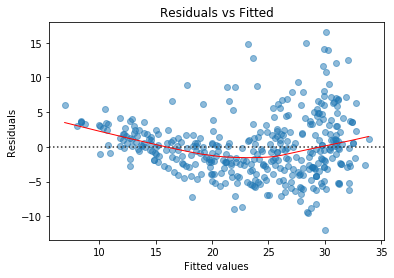

```python
import matplotlib.pyplot as plt
import seaborn as sns

fitted = results.fittedvalues
plot = plt.figure()
plot.axes[0] = sns.residplot(fitted, 'mpg', data=auto, lowess=True, scatter_kws={'alpha': 0.5},
                          line_kws={'color': 'red', 'lw': 1, 'alpha': 1})
txt = plot.axes[0].set_title('Residuals vs Fitted')
txt = plot.axes[0].set_xlabel('Fitted values')
txt = plot.axes[0].set_ylabel('Residuals')
```

This residuals vs. fitted plot suggests the non-linearity in the data.

# Exercise 3

**This question involves the use of multiple linear regression on the `Auto` data set.**

### (a)

**Produce a scatterplot matrix which includes all of the variables in the data set using `pandas.plotting.scatter_matrix`.**

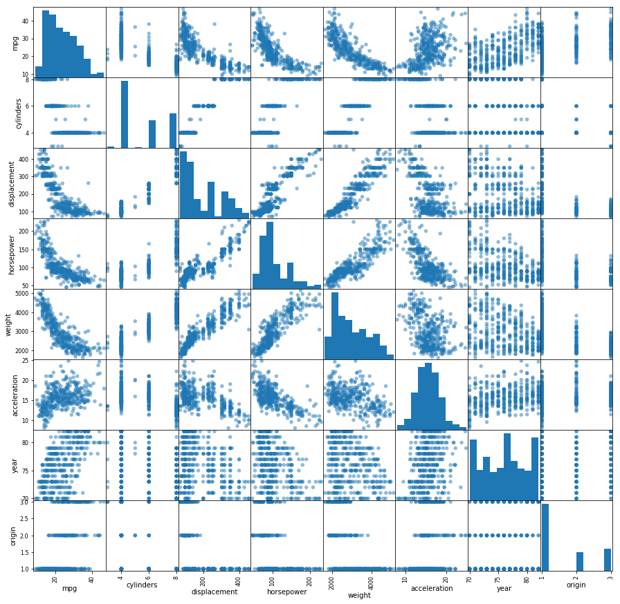

```python
import pandas as pd
plot = pd.plotting.scatter_matrix(auto, figsize=(15,15), marker='o', s=30, alpha=.5)
```

### (b)

**Compute the matrix of correlations between the variables using the `corr()` attribute in Pandas.**

```python
auto.corr()
```

|  | mpg | cylinders | displacement | horsepower | weight | acceleration | year | origin |
| --- | --- | --- | --- | --- | --- | --- | --- | --- |
| mpg | 1.000000 | -0.777618 | -0.805127 | -0.778427 | -0.832244 | 0.423329 | 0.580541 | 0.565209 |
| cylinders | -0.777618 | 1.000000 | 0.950823 | 0.842983 | 0.897527 | -0.504683 | -0.345647 | -0.568932 |
| displacement | -0.805127 | 0.950823 | 1.000000 | 0.897257 | 0.932994 | -0.543800 | -0.369855 | -0.614535 |
| horsepower | -0.778427 | 0.842983 | 0.897257 | 1.000000 | 0.864538 | -0.689196 | -0.416361 | -0.455171 |
| weight | -0.832244 | 0.897527 | 0.932994 | 0.864538 | 1.000000 | -0.416839 | -0.309120 | -0.585005 |
| acceleration | 0.423329 | -0.504683 | -0.543800 | -0.689196 | -0.416839 | 1.000000 | 0.290316 | 0.212746 |
| year | 0.580541 | -0.345647 | -0.369855 | -0.416361 | -0.309120 | 0.290316 | 1.000000 | 0.181528 |
| origin | 0.565209 | -0.568932 | -0.614535 | -0.455171 | -0.585005 | 0.212746 | 0.181528 | 1.000000 |

### (c)

**Use the `OLS` function from the `statsmodels` package to perform a multiple linear regression with `mpg` as the response and all other variables except `name` as the predictors. Be sure to include an intercept. Print the results. Comment on the output.**

```python
import statsmodels.api as sm
X = sm.add_constant(auto[auto.columns[1:8]])
model = sm.OLS(auto['mpg'], X)
results = model.fit()
print(results.summary())
```

```
                            OLS Regression Results
==============================================================================
Dep. Variable:                    mpg   R-squared:                       0.821
Model:                            OLS   Adj. R-squared:                  0.818
Method:                 Least Squares   F-statistic:                     252.4
Date:                Thu, 18 Apr 2019   Prob (F-statistic):          2.04e-139
Time:                        22:47:14   Log-Likelihood:                -1023.5
No. Observations:                 392   AIC:                             2063.
Df Residuals:                     384   BIC:                             2095.
Df Model:                           7
Covariance Type:            nonrobust
================================================================================
                   coef    std err          t      P>|t|      [0.025      0.975]
--------------------------------------------------------------------------------
const          -17.2184      4.644     -3.707      0.000     -26.350      -8.087
cylinders       -0.4934      0.323     -1.526      0.128      -1.129       0.142
displacement     0.0199      0.008      2.647      0.008       0.005       0.035
horsepower      -0.0170      0.014     -1.230      0.220      -0.044       0.010
weight          -0.0065      0.001     -9.929      0.000      -0.008      -0.005
acceleration     0.0806      0.099      0.815      0.415      -0.114       0.275
year             0.7508      0.051     14.729      0.000       0.651       0.851
origin           1.4261      0.278      5.127      0.000       0.879       1.973
==============================================================================
Omnibus:                       31.906   Durbin-Watson:                   1.309
Prob(Omnibus):                  0.000   Jarque-Bera (JB):               53.100
Skew:                           0.529   Prob(JB):                     2.95e-12
Kurtosis:                       4.460   Cond. No.                     8.59e+04
==============================================================================

Warnings:
[1] Standard Errors assume that the covariance matrix of the errors is correctly specified.
[2] The condition number is large, 8.59e+04. This might indicate that there are
strong multicollinearity or other numerical problems.
```

**(i) Is there a relationship between the predictors and the response?**

The p-value of the F-statistic is 2.04e-139, which is pretty closed to zero, so we reject the null hypothesis. There is a relationship between the predictors and the response.

**(ii) Which predictors appear to have a statistically significant relationship to the response?**

The predictors displacement, weight, year and origin have a statistically significant relationship to the response mpg. Their associated p-value are smaller than 0.05.

**(iii) What does the coefficient for the year variable suggest?**

The coefficient for the year variable is 0.7508, which suggests that, when keeping other predictors fixed, mpg has a increase of 0.7508 for every increase of a year. This also means that automobiles become more efficient with the increase of year.

### (d)

**Plot the residuals vs. fitted values. Comment on any problems you see with the fit.**

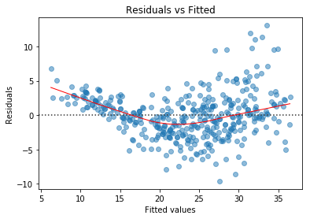

```python
import matplotlib.pyplot as plt
import seaborn as sns

fitted = results.fittedvalues
plot = plt.figure(1)
plot.axes[0] = sns.residplot(fitted, 'mpg', data=auto, lowess=True, scatter_kws={'alpha': 0.5},
                          line_kws={'color': 'red', 'lw': 1, 'alpha': 1})
txt = plot.axes[0].set_title('Residuals vs Fitted')
txt = plot.axes[0].set_xlabel('Fitted values')
txt = plot.axes[0].set_ylabel('Residuals')
```

This residuals vs. fitted plot suggests the non-linearity in the data.

### (e)

**Statsmodels allows you to fit models using R-style formulas. See http://www.statsmodels.org/dev/example_formulas.html. Use the * and : symbols to fit linear regression models with interaction effects. Do any interactions appear to be statistically significant?**

```python
import statsmodels.formula.api as smf

model = smf.ols(formula='mpg ~ cylinders + displacement + horsepower + weight + acceleration + year + origin + '
                'cylinders : displacement + horsepower : weight', data=auto)
results = model.fit()
print(results.summary())
```

```
                            OLS Regression Results
==============================================================================
Dep. Variable:                    mpg   R-squared:                       0.863
Model:                            OLS   Adj. R-squared:                  0.860
Method:                 Least Squares   F-statistic:                     267.4
Date:                Thu, 18 Apr 2019   Prob (F-statistic):          6.52e-159
Time:                        22:47:14   Log-Likelihood:                -971.56
No. Observations:                 392   AIC:                             1963.
Df Residuals:                     382   BIC:                             2003.
Df Model:                           9
Covariance Type:            nonrobust
==========================================================================================
                             coef    std err          t      P>|t|      [0.025      0.975]
------------------------------------------------------------------------------------------
Intercept                  4.0528      4.544      0.892      0.373      -4.881      12.986
cylinders                 -0.7357      0.483     -1.522      0.129      -1.686       0.215
displacement              -0.0201      0.016     -1.269      0.205      -0.051       0.011
horsepower                -0.2080      0.027     -7.754      0.000      -0.261      -0.155
weight                    -0.0101      0.001    -10.849      0.000      -0.012      -0.008
acceleration              -0.0706      0.089     -0.793      0.428      -0.245       0.104
year                       0.7692      0.045     17.168      0.000       0.681       0.857
origin                     0.7159      0.259      2.765      0.006       0.207       1.225
cylinders:displacement     0.0039      0.002      1.816      0.070      -0.000       0.008
horsepower:weight       4.699e-05   6.93e-06      6.781      0.000    3.34e-05    6.06e-05
==============================================================================
Omnibus:                       41.771   Durbin-Watson:                   1.489
Prob(Omnibus):                  0.000   Jarque-Bera (JB):               81.626
Skew:                           0.609   Prob(JB):                     1.88e-18
Kurtosis:                       4.875   Cond. No.                     1.24e+07
==============================================================================

Warnings:
[1] Standard Errors assume that the covariance matrix of the errors is correctly specified.
[2] The condition number is large, 1.24e+07. This might indicate that there are
strong multicollinearity or other numerical problems.
```

From the correlation matrix, we can observe that there are strong positive linear correlations among cylinders, displacement, horsepower and weight. In this model, two interactions, cylinders:displacement and horsepower:weight are added. The interaction horsepower:weight has an associated p-value smaller than 0.05, so it is statistically significant.

### (f)

**Try a few different transformations of the variables, such as $log(X)$, $\sqrt X$, $X^2$ . Comment on your findings.**

```python
import statsmodels.formula.api as smf
import numpy as np

model = smf.ols(formula='mpg ~ displacement.pow(.5) + horsepower.pow(2) + np.log(weight) + year.pow(2)', data=auto)
results = model.fit()
print(results.summary())
```

```
                            OLS Regression Results
==============================================================================
Dep. Variable:                    mpg   R-squared:                       0.840
Model:                            OLS   Adj. R-squared:                  0.839
Method:                 Least Squares   F-statistic:                     509.6
Date:                Thu, 18 Apr 2019   Prob (F-statistic):          9.69e-153
Time:                        22:47:14   Log-Likelihood:                -1001.5
No. Observations:                 392   AIC:                             2013.
Df Residuals:                     387   BIC:                             2033.
Df Model:                           4
Covariance Type:            nonrobust
========================================================================================
                           coef    std err          t      P>|t|      [0.025      0.975]
----------------------------------------------------------------------------------------
Intercept              155.7779     11.201     13.908      0.000     133.756     177.800
displacement.pow(.5)    -0.1346      0.141     -0.953      0.341      -0.412       0.143
horsepower.pow(2)      5.86e-05   3.05e-05      1.920      0.056   -1.39e-06       0.000
np.log(weight)         -20.3466      1.611    -12.633      0.000     -23.513     -17.180
year.pow(2)              0.0053      0.000     16.911      0.000       0.005       0.006
==============================================================================
Omnibus:                       58.831   Durbin-Watson:                   1.331
Prob(Omnibus):                  0.000   Jarque-Bera (JB):              139.963
Skew:                           0.758   Prob(JB):                     4.05e-31
Kurtosis:                       5.504   Cond. No.                     1.17e+06
==============================================================================

Warnings:
[1] Standard Errors assume that the covariance matrix of the errors is correctly specified.
[2] The condition number is large, 1.17e+06. This might indicate that there are
strong multicollinearity or other numerical problems.
```

In this model, $log(weight)$ and $year^2$ have p-value smaller than 0.05, giving statistically significance.

# Exercise 4

**This problem involves simple linear regression without an intercept.**

### (a)

**Recall that the coefficient estimate $\beta$ for the linear regression of $Y$ onto $X$ without an intercept is given by (3.38). Under what circumstance is the coefficient estimate for the regression of $X$ onto $Y$ the same as the coefficient estimate for the regression of $Y$ onto $X$?**

The coefficient estimate $\beta$ for the linear regression of $Y$ onto $X$ without an intercept is given by

$$\hat \beta = \frac {\sum_{i=1}^n x_i y_i} {\sum_{i^\prime=1}^n x_{i^\prime}^2} $$

The coefficient estimate $\beta$ for the linear regression of $X$ onto $Y$ without an intercept is given by

$$\hat \beta = \frac {\sum_{i=1}^n x_i y_i} {\sum_{i^\prime=1}^n y_{i^\prime}^2} $$

So the coefficient estimate for the regression of $X$ onto $Y$ the same as the coefficient estimate for the regression of $Y$ onto $X$ when $\sum_{i^\prime=1}^n x_{i^\prime}^2 = \sum_{i^\prime=1}^n y_{i^\prime}^2$.

### (b)

**Generate an example in Python with $n = 50$ observations in which the coefficient estimate for the regression of $X$ onto $Y$ is different from the coefficient estimate for the regression of $Y$ onto $X$.**

```python
import numpy as np
import pandas as pd

np.random.seed(0)
# Set x to be [1,2,3,...,49,50]
x = np.array(range(1,51))
X = pd.DataFrame(x, columns=['X'])

# Set y to be x plus normally randomly picked 50 difference
y = x + np.random.normal(loc=0,size=50)
Y = pd.DataFrame(y, columns=['Y'])
```

```python
sum(x ** 2)
```

```
42925
```

```python
sum(y ** 2)
```

```
42747.814522563946
```

In this case, $\sum_{i^\prime=1}^n x_{i^\prime}^2 \neq \sum_{i^\prime=1}^n y_{i^\prime}^2$. So the coefficient estimate for the regression of $X$ onto $Y$ is supposed to be different from the coefficient estimate for the regression of $Y$ onto $X$.

```python
import statsmodels.api as sm
model1 = sm.OLS(X,Y)
result1 = model1.fit()
print(result1.summary())
```

```
                            OLS Regression Results
==============================================================================
Dep. Variable:                      X   R-squared:                       0.999
Model:                            OLS   Adj. R-squared:                  0.998
Method:                 Least Squares   F-statistic:                 3.269e+04
Date:                Thu, 18 Apr 2019   Prob (F-statistic):           7.03e-71
Time:                        22:47:14   Log-Likelihood:                -77.217
No. Observations:                  50   AIC:                             156.4
Df Residuals:                      49   BIC:                             158.3
Df Model:                           1
Covariance Type:            nonrobust
==============================================================================
                 coef    std err          t      P>|t|      [0.025      0.975]
------------------------------------------------------------------------------
Y              1.0013      0.006    180.792      0.000       0.990       1.012
==============================================================================
Omnibus:                        0.466   Durbin-Watson:                   1.775
Prob(Omnibus):                  0.792   Jarque-Bera (JB):                0.617
Skew:                           0.131   Prob(JB):                        0.734
Kurtosis:                       2.523   Cond. No.                         1.00
==============================================================================

Warnings:
[1] Standard Errors assume that the covariance matrix of the errors is correctly specified.
```

```python
model2 = sm.OLS(Y,X)
result2 = model2.fit()
print(result2.summary())
```

```
                            OLS Regression Results
==============================================================================
Dep. Variable:                      Y   R-squared:                       0.999
Model:                            OLS   Adj. R-squared:                  0.998
Method:                 Least Squares   F-statistic:                 3.269e+04
Date:                Thu, 18 Apr 2019   Prob (F-statistic):           7.03e-71
Time:                        22:47:14   Log-Likelihood:                -77.114
No. Observations:                  50   AIC:                             156.2
Df Residuals:                      49   BIC:                             158.1
Df Model:                           1
Covariance Type:            nonrobust
==============================================================================
                 coef    std err          t      P>|t|      [0.025      0.975]
------------------------------------------------------------------------------
X              0.9972      0.006    180.792      0.000       0.986       1.008
==============================================================================
Omnibus:                        0.411   Durbin-Watson:                   1.777
Prob(Omnibus):                  0.814   Jarque-Bera (JB):                0.575
Skew:                          -0.130   Prob(JB):                        0.750
Kurtosis:                       2.543   Cond. No.                         1.00
==============================================================================

Warnings:
[1] Standard Errors assume that the covariance matrix of the errors is correctly specified.
```

The coefficient estimate for the regression of $X$ onto $Y$ is 1.0013.

The coefficient estimate for the regression of $Y$ onto $X$ is 0.9972.

They are different.

### (c)

**Generate an example in Python with $n = 50$ observations in which the coefficient estimate for the regression of $X$ onto $Y$ is the same as the coefficient estimate for the regression of $Y$ onto $X$.**

```python
import numpy as np
import pandas as pd

# Set x to be [1,2,3,...,49,50]
x = np.array(range(1,51))
X = pd.DataFrame(x, columns=['X'])

# Set y to be [50,49,48,...,2,1]
y = np.array(range(50,0,-1))
Y = pd.DataFrame(y, columns=['Y'])
```

```python
sum(x ** 2)
```

```
42925
```

```python
sum(y ** 2)
```

```
42925
```

In this case, $\sum_{i^\prime=1}^n x_{i^\prime}^2 = \sum_{i^\prime=1}^n y_{i^\prime}^2$. So the coefficient estimate for the regression of $X$ onto $Y$ is supposed to be the same as the coefficient estimate for the regression of $Y$ onto $X$.

```python
import statsmodels.api as sm
model1 = sm.OLS(X,Y)
result1 = model1.fit()
print(result1.summary())
```

```
                            OLS Regression Results
==============================================================================
Dep. Variable:                      X   R-squared:                       0.265
Model:                            OLS   Adj. R-squared:                  0.250
Method:                 Least Squares   F-statistic:                     17.67
Date:                Thu, 18 Apr 2019   Prob (F-statistic):           0.000111
Time:                        22:47:14   Log-Likelihood:                -232.13
No. Observations:                  50   AIC:                             466.3
Df Residuals:                      49   BIC:                             468.2
Df Model:                           1
Covariance Type:            nonrobust
==============================================================================
                 coef    std err          t      P>|t|      [0.025      0.975]
------------------------------------------------------------------------------
Y              0.5149      0.122      4.204      0.000       0.269       0.761
==============================================================================
Omnibus:                       11.811   Durbin-Watson:                   0.004
Prob(Omnibus):                  0.003   Jarque-Bera (JB):                3.005
Skew:                          -0.000   Prob(JB):                        0.223
Kurtosis:                       1.799   Cond. No.                         1.00
==============================================================================

Warnings:
[1] Standard Errors assume that the covariance matrix of the errors is correctly specified.
```

```python
model2 = sm.OLS(Y,X)
result2 = model2.fit()
print(result2.summary())
```

```
                            OLS Regression Results
==============================================================================
Dep. Variable:                      Y   R-squared:                       0.265
Model:                            OLS   Adj. R-squared:                  0.250
Method:                 Least Squares   F-statistic:                     17.67
Date:                Thu, 18 Apr 2019   Prob (F-statistic):           0.000111
Time:                        22:47:14   Log-Likelihood:                -232.13
No. Observations:                  50   AIC:                             466.3
Df Residuals:                      49   BIC:                             468.2
Df Model:                           1
Covariance Type:            nonrobust
==============================================================================
                 coef    std err          t      P>|t|      [0.025      0.975]
------------------------------------------------------------------------------
X              0.5149      0.122      4.204      0.000       0.269       0.761
==============================================================================
Omnibus:                       11.811   Durbin-Watson:                   0.004
Prob(Omnibus):                  0.003   Jarque-Bera (JB):                3.005
Skew:                           0.000   Prob(JB):                        0.223
Kurtosis:                       1.799   Cond. No.                         1.00
==============================================================================

Warnings:
[1] Standard Errors assume that the covariance matrix of the errors is correctly specified.
```

The coefficient estimate for the regression of $X$ onto $Y$ is 0.5149.

The coefficient estimate for the regression of $Y$ onto $X$ is 0.5149.

They are the same.